# TP1 : Introduction à l'algorithmique et à Python

## NOM ETUDIANT : (à remplir)

## Variables, typage dynamique et instructions de contrôle

Chaque notebook de TP est à déposer sur moodle dans la zone de dépôt dédiée, au plus tard, la semaine suivant le TP. Ce dépôt tient lieu de compte-rendu et sera évalué.

Le nom de votre fichier .ipynb doit contenir votre nom. Exemple : TP1_PYTHON_DUPONT.ipynb

### Bonnes pratiques :

```
 - les noms de variables et de constantes doivent être explicites sauf s'il existe des conventions                        par exemple i,j,k pour les indices ;
 - le code doit être commenté lorsque les actions réalisées sont complexes
     les commentaires doivent refléter l'algorithme sous-jacent ;
 - chaque programme doit faire l'objet des tests des cas limite et d'un rapport de tests
     tester le fonctionnement normal, ainsi que les cas d'erreur potentiels.
```

Le code est écrit dans une cellule code et les rapports de tests par copie-coller des résultats des tests successifs, et ce, en dessous du texte de l'exercice.

Un rapport de test s'accompagne de messages explicitant la demande de saisie ou bien la nature de la valeur affichée. On doit comprendre la nature du test effectué.

Par exemple

Saisir une valeur Valeur lue = 8 Valeur binarisée = 0

Ceci notebook tient lieu de compte-rendu de TP.Faire une version html (File > Save and Export Notebook as > choix html)

## RENDU :

1. Renommer votre notebbok en incluant votre NOM --> TP1_PYTHON_ETUD_VOTRE_NOM.ipynb
2. Faire une version html (File > Save and Export Notebook as > choix html) du notebook (cela permet de visialiser rapidement le travail effectivement réalisé)
3. Faire une archive avec la version ipynb et la version html
4. Déposer l'archive sur moodle dans la zonne de dépôt dédiée.

```python
#  A NOTER
# les commandes UNIX à exécuter depuis un notebook doivent être précédées de !
# pour que le changement de répertoire soit effectif la commande cd doit être précédée de %

# vérifier où on se trouve dans l'arborescence des fichiers ... quelques commandes UNIX de base
!pwd; ls;
#!mkdir TP1_VOTRE_NOM
#%cd chemin_vers_le_répertoire
#!pwd; ls;

# marque un commentaire
```

```python
! pip install ipykernel
```

```
^C
```

### EXERCICE 1 : Instructions conditionnelles

Un pixel est un constituant de base d'une image. Il correspond à une valeur entière qui représente une intensité. Les valeurs des pixels sont comprises entre 0 et 255 (256 valeurs possibles).

Dans une image noir et blanc on considère que 1 correspond au BLANC et 0 au NOIR. Dans une image en niveaux de gris on considère toute la palette des gris en allant du noir (0) au blanc (255) en passant par tous les degrés de gris possible du plus foncé au plus clair.

#### Exercice 1.1 :

Dans ce contexte, écrire un programme python qui lit une valeur de pixel au clavier, teste les cas limite et affiche le message approprié :

- valeur comprise dans l'intervalle de définition --> message 'valeur valide'
- valeur non comprise dans cet intervalle --> message 'valeur non valide'

Tester avec les cas suivants et copier-coller le rapport de tests ci-dessous : 300, -15, 0, 123, 1.5, "pixel"

```python
# Exercice 1.1
max_pixel=255
min_pixel=0
valeur = int(input("Veuillez entrer une valeur de pixel de votre choix compris en 0 et 255 :"))

if (valeur<=max_pixel and valeur>=min_pixel):
    print("Valeur valide")
else:
    print("Valeur non valide")
```

```
Valeur valide
```

300 --> Valeur non valide -15 --> Valeur non valide 0 --> Valeur valide 123 -->Valeur valide 1.5 -->ValueError: invalid literal for int() with base 10: '1.5' "pixel" --> ValueError: invalid literal for int() with base 10: 'pixel'

#### Exercice 1.2 : en partant de la copie du programme précédent modifier le code pour avoir les cas suivants

- valeur négative --> message 'la valeur fournie doit être positive'
- valeur supérieure --> message 'la valeur fournie est trop grande '
- valleur correct --> message 'la valeur fournie est correcte'

Effectuer les mêmes tests que précédemment et copier-coller le rapport de tests : 300, -15, 0, 123, 1.5, "pixel"

```python
          # Exercice 1.2
max_pixel=255
min_pixel=0

valeur = int(input("Veuillez entrer une valeur de pixel de votre choix :"))

if (valeur<= max_pixel and valeur>=min_pixel):
    print("la valeur est valide")

elif (valeur<0):
    print("la valeur fournie doit etre positif")

elif (valeur>max_pixel):
    print("la valeur fournie est trop grande")

else:
    print("Valeur non valide")
```

[output not shown]

#### Exercice 1.3 : en partant de la copie du programme précédent modifier le code pour avoir les cas suivants

- valeur négative --> message 'la valeur fournie doit être positive'
- valeur supérieure --> message 'la valeur fournie est trop grande '
- ou bien procède à la binarisation du pixel en calculant la valeur pixel_bin (0 ou 1) et en affichant le message suivant

'valeur binarisée = pixel_bin'  
soit 0 pour NOIR et 1 pour BLANC

Effectuer les tests sur les valeurs suivantes et copier-coller le rapport de tests ci-dessous : Valeurs de test : -15, 0, 110, 136, 224, 256, ...

```python
          # Exercice 1.3
max_pixel=255
min_pixel=0
seuil_pixel=256//2

valeur = int(input("Veuillez entrer une valeur de pixel de votre choix :"))

if (valeur<= max_pixel and valeur>=min_pixel):

    print("la valeur est valide")

    print("seuil_pixel=",seuil_pixel)

    if(valeur>=seuil_pixel):
        valeur=1
        print("valeur binarisée=",valeur)

    else:
        valeur=0
        print("valeur binarisée=",valeur)

elif (valeur<0):
    print("la valeur fournie doit etre positif")


elif (valeur>max_pixel):
    print("la valeur fournie est trop grande")


else:
    print("Valeur non valide")
```

```
la valeur est valide
seuil_pixel= 128
valeur binarisée= 0
```

-15 --> la valeur fournie doit etre positif

0 -->la valeur est valide seuil_pixel= 128 binarisée= 0

110 -->la valeur est valide seuil_pixel= 128 valeur binarisée= 0

136 -->la valeur est valide seuil_pixel= 128 valeur binarisée= 1

224 -->la valeur est valide seuil_pixel= 128 valeur binarisée= 1

256 -->la valeur fournie est trop grande

#### Exercice 1.4 : en partant de la copie du programme précédent modifier le code pour obtenir le traitement suivant :

procéder à la transformation sur 4 niveaux de gris du pixel en calculant la valeur pixel_4n et en affichant le message --> 'valeur sur 4 niveaux de gris = pixel_4n

de façon à avoir pixel_4n --> 0 = NOIR ; 1 = GRIS FONCE ; 2 = GRIS CLAIR = ; 3 = BLANC

Effectuer les tests sur les valeurs suivantes et copier-coller le rapport de tests : 0, 50, 110, 130, 200, 300

```python
          # Exercice 1.4
max_pixel=255
min_pixel=0
seuil_pixel=256//4
pixel_seui1=seuil_pixel
pixel_seui2=seuil_pixel*2
pixel_seui3=seuil_pixel*3


valeur = int(input("Veuillez entrer une valeur de pixel de votre choix:"))

if (valeur<= max_pixel and valeur>=min_pixel):

    print("la valeur est valide")



    if(valeur<pixel_seui1):
        valeur=0
        print("valeur sur 4 niveau de gris=",valeur)


    elif(valeur<pixel_seui2):
        valeur=1
        print("valeur sur 4 niveau de gris=",valeur)


    elif(valeur<pixel_seui3):
            valeur=2
            print("valeur sur 4 niveau de gris=",valeur)


    else:
        valeur=3
        print("valeur sur 4 niveau de gris=",valeur)

elif (valeur<0):
    print("la valeur fournie doit etre positif")


elif (valeur>max_pixel):

    print("la valeur fournie est trop grande")


else:
    print("Valeur non valide")
```

```
la valeur est valide
valeur sur 4 niveau de gris= 3
```

0 -->la valeur est valide valeur sur 4 niveau de gris= 0

50 -->la valeur est valide valeur sur 4 niveau de gris= 0

110 -->la valeur est valide valeur sur 4 niveau de gris= 1

130 -->la valeur est valide valeur sur 4 niveau de gris= 2

200 -->la valeur est valide valeur sur 4 niveau de gris= 3

300 -->la valeur fournie est trop grande

#### Exercice 1.5 : en partant de la copie du programme précédent modifier le code pour obtenir le traitement suivant :

généraliser le traitement pour ramener la valeur du pixel à un autre nombre de niveaux de gris (nb_niveaux) en calculant la valeur pixel_Nb et en affichant le message 'valeur sur nb_niveaux de gris = pixel_Nb' dans la mesure ou nb_niveaux est :

- (1) lu au clavier
- (2) doit être compris entre 1 et 255
- (3) correspondre à une puissance de 2

Le programme devra vérifier la validité de nb_niveaux avant de procéder à la lecture et au traitement du pixel.

Si la valeur n'est pas valide le message 'la valeur fournie pour nb_niveaux n'est pas valide' sera affiché (ainsi que la raison : soit en dehors de l'intervalle ou bien dans l'intervalle mais pas une puissance de 2.

En cas de validité de nb_niveaux, le traitement sera effectué et le message prévu affiché

Vous utiliserez pour cela la bibliothèque math que vous aurez importée au préalable avec

```
import math
```

sachant que la fonction log2(x) de cette bibliothèque doit vous aider à faire le test puissance de 2 ou pas

Effectuer les tests sur les valeurs suivantes et copier-coller le rapport de tests ci-dessous : 300, 15, 16, 8, 0, ...

```python
# Bibliothèque mathématique Python
import math
max_pixel=255
min_pixel=1



valeur = int(input("Veuillez entrer une valeur de pixel de votre choix :"))
b=True
while(b):
    nb_niveau=int(input("Veuillez entrer le nombre de niveau :"))
    #x.type()=type(2)
    if(nb_niveau>0):
        if(math.log2(nb_niveau).is_integer()):
            b=False
        else:
            print("Le nombre de niveau doit etre un entier puissance de 2.")
    else:
        print("Le nombre de niveau doit etre un entier positif et different de zero.")

if (valeur<= max_pixel and valeur>=min_pixel):

    print("la valeur est valide")

    for i in range(nb_niveau):
        if(valeur<(i+1)*(256//nb_niveau)):
            valeur=i
            print("valeur sur ",nb_niveau," niveau de gris=",valeur)
            break

elif (valeur<0):
    print("la valeur fournie doit etre positif")


elif (valeur>max_pixel):

    print("la valeur fournie est trop grande")


else:
    print("Valeur non valide")
```

```
la valeur est valide
valeur sur  8  niveau de gris= 0
```

300 -->la valeur fournie est trop grande

15 -->la valeur est valide valeur sur 4 niveau de gris= 0

16 -->la valeur est valide valeur sur 16 niveau de gris= 1

8 -->la valeur est valide valeur sur 8 niveau de gris= 0

### Exercice 2 : Structures de données, traitements itératifs et gestion de tableaux à une dimension

Exécuter et tester le code suivant. Que fait ce code ?

```python
# Constante
MAX = 16
# Variables
tab = []
long_tab = len(tab)

# Contenu tableau
print('tableau ', tab, 'de longueur ', long_tab)

# Saisie taille tableau
long_tab = int(input('Donner la longueur du tableau < à 16\n'))

if long_tab < 0 or long_tab > MAX:
    print('Valeur non valide')
else:
    for i in range (long_tab):
        tab.append(0)
    print('tableau ', tab, 'de longueur ', long_tab)
```

```
tableau  [] de longueur  0
tableau  [0, 0, 0, 0, 0, 0, 0, 0] de longueur  8
```

ce code apprend un tableau vide lui attribut une taille et initialise toute les valeurs a 0 tableau [] de longueur 0 tableau [0, 0, 0, 0, 0, 0, 0, 0] de longueur 8

#### Exercice 2.1 : en partant de la copie du programme précédent modifier le code pour obtenir le traitement suivant :

générer un tableau correspondant aux 16 valeurs suivantes [0, 15, 30, 45, 60, 75, 90, 105, 120, 135, 150, 165, 180, 195, 210, 225]

Copier le résultat obtenu ci-dessous

```python
# Constante
MAX = 16
# Variables
tab = []
long_tab = len(tab)

#valeur du contenu du tableau
x=0
# Contenu tableau
print('tableau ', tab, 'de longueur ', long_tab)

# Saisie taille tableau
long_tab = int(input('Donner la longueur du tableau <= à 16\n'))

if long_tab < 0 or long_tab > MAX:
    print('Valeur non valide')
else:
    for i in range (long_tab):
        tab.append(x)
        x+=15
    print('tableau ', tab, 'de longueur ', long_tab)
```

```
tableau  [] de longueur  0
tableau  [0, 15, 30, 45, 60, 75, 90, 105, 120, 135, 150, 165, 180, 195, 210, 225] de longueur  16
```

tableau [] de longueur 0 tableau [0,15, 30, 45, 60, 75, 90, 105, 120, 135, 150, 165, 180, 195, 210, 225] de longueur 16

#### Exercice 2.2 : en partant des codes précédents, modifier le code pour obtenir le traitement suivant :

En considérant que le tableau obtenu précédemment est la première ligne d'une image de 16 pixels, écrire le code qui permet de faire une copie de cette ligne et de la transformer de façon à : a) la binariser b) la mettre sur 4 niveaux de gris c) la mettre sur 8 niveaux de gris.

On considèrera que les valeurs des pixels sont valides, pour éviter les mauvaises surprises, vérifier que les tableaux ont des identifiants différents

```python
# Constante
MAX = 16
seuil_pixel=256//2
seuil_pixel1=256//4
pixel_seui1=seuil_pixel1
pixel_seui2=seuil_pixel1*2
pixel_seui3=seuil_pixel1*3

# Variables
tab = []
long_tab = len(tab)

#valeur du contenu du tableau
x=0
# Contenu tableau
print('tableau ', tab, 'de longueur ', long_tab," id:",id(tab))

# Saisie taille tableau
long_tab = int(input('Donner la longueur du tableau < à 17\n'))

if long_tab < 0 or long_tab > MAX:
    print('Valeur non valide')
else:
    for i in range (long_tab):
        tab.append(x)
        x+=15
    print('tableau ', tab, 'de longueur ', long_tab," id:",id(tab))

    copie_tab_bin = tab.copy()
    copie_tab_4level = tab.copy()
    copie_tab_8level = tab.copy()
    for i in range (long_tab):

        # Binarisation
        if(copie_tab_bin[i]>=seuil_pixel):
                copie_tab_bin[i]=1
        else:
            copie_tab_bin[i]=0


        # sur 4 niveau de gris
        if(copie_tab_4level[i]<pixel_seui1):
            copie_tab_4level[i]=0


        elif(copie_tab_4level[i]<pixel_seui2):
            copie_tab_4level[i]=1


        elif(copie_tab_4level[i]<pixel_seui3):
            copie_tab_4level[i]=2

        else:
            copie_tab_4level[i]=3

        # sur 8 niveau de gris
        if(copie_tab_8level[i]<(256//8)):
            copie_tab_8level[i]=0

        elif(copie_tab_8level[i]<(256//8)*2):
            copie_tab_8level[i]=1

        elif(copie_tab_8level[i]<(256//8)*3):
            copie_tab_8level[i]=2

        elif(copie_tab_8level[i]<(256//8)*4):
            copie_tab_8level[i]=3

        elif(copie_tab_8level[i]<(256//8)*5):
            copie_tab_8level[i]=4

        elif(copie_tab_8level[i]<(256//8)*6):
            copie_tab_8level[i]=5

        elif(copie_tab_8level[i]<(256//8)*7):
            copie_tab_8level[i]=6

        else:
            copie_tab_8level[i]=7

    print('tableau binarisé ', copie_tab_bin, 'de longueur ', long_tab," id:",id(copie_tab_bin))
    print('tableau sur 4 niveaux de gris ', copie_tab_4level, 'de longueur ', long_tab," id:",id(copie_tab_4level))
    print('tableau sur 8 niveaux de gris ', copie_tab_8level, 'de longueur ', long_tab," id:",id(copie_tab_8level))
```

```
tableau  [] de longueur  0  id: 1566317383040
tableau  [0, 15, 30, 45, 60, 75, 90, 105, 120, 135, 150, 165, 180, 195, 210, 225] de longueur  16  id: 1566317383040
tableau binarisé  [0, 0, 0, 0, 0, 0, 0, 0, 0, 1, 1, 1, 1, 1, 1, 1] de longueur  16  id: 1566317326848
tableau sur 4 niveaux de gris  [0, 0, 0, 0, 0, 1, 1, 1, 1, 2, 2, 2, 2, 3, 3, 3] de longueur  16  id: 1566141786880
tableau sur 8 niveaux de gris  [0, 0, 0, 1, 1, 2, 2, 3, 3, 4, 4, 5, 5, 6, 6, 7] de longueur  16  id: 1566141780480
```

tableau [] de longueur 0 id: 1566317383040

tableau [0, 15, 30, 45, 60, 75, 90, 105, 120, 135, 150, 165, 180, 195, 210, 225] de longueur 16 id: 1566317383040

tableau binarisé [0, 0, 0, 0, 0, 0, 0, 0, 0, 1, 1, 1, 1, 1, 1, 1] de longueur 16 id: 1566317326848

tableau sur 4 niveaux de gris [0, 0, 0, 0, 0, 1, 1, 1, 1, 2, 2, 2, 2, 3, 3, 3] de longueur 16 id: 1566141786880

tableau sur 8 niveaux de gris [0, 0, 0, 1, 1, 2, 2, 3, 3, 4, 4, 5, 5, 6, 6, 7] de longueur 16 id: 1566141780480

### Exercice 3 : Structures de données, traitements itératifs et gestion de tableaux à deux dimensions

#### Exercice 3.1 :

Une image de 16 x 16 pixels peut être créée en recopiant automatiquement 16 fois la valeur du tableau initial. On a ainsi une liste de listes que l'on peut interpréter comme une image en niveau de gris. Pour cela, exécuter le code suivant et étudiez-le.

```
[0, 15, 30, 45, 60, 75, 90, 105, 120, 135, 150, 165, 180, 195, 210, 225]
----- 1566264915520
----- 1566264906432
----- 1566264079616
----- 1566317316800
----- 1566317316672
----- 1566317316864
----- 1566317317248
----- 1566317415168
----- 1566317321472
----- 1566317415104
----- 1566317414912
----- 1566317416832
----- 1566317415616
----- 1566317416768
----- 1566317416576
----- 1566316661696
liste de liste  <class 'list'>
 <class 'list'>
 [[0, 15, 30, 45, 60, 75, 90, 105, 120, 135, 150, 165, 180, 195, 210, 225], [0, 15, 30, 45, 60, 75, 90, 105, 120, 135, 150, 165, 180, 195, 210, 225], [0, 15, 30, 45, 60, 75, 90, 105, 120, 135, 150, 165, 180, 195, 210, 225], [0, 15, 30, 45, 60, 75, 90, 105, 120, 135, 150, 165, 180, 195, 210, 225], [0…
```

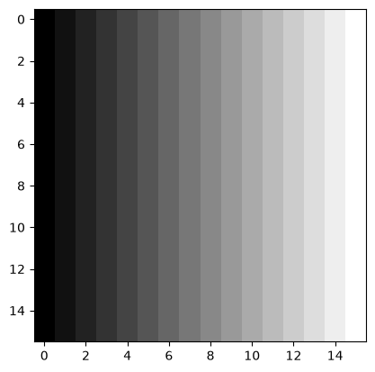

```python
import matplotlib as mp
from matplotlib import pyplot

print(tab)
long_tab = len(tab)
mon_image = []

# construction de l'image à partir de copies de la ligne tab
for i in range(long_tab):
    mon_image.append(tab.copy())
    # vérification des identifiants --> ils doivent être différents
    print('-----', id(mon_image[i]))

print('liste de liste ', type(mon_image), '\n',type(mon_image[0]), '\n', mon_image)
# visualisation de l'image en iveau de gris
mp.pyplot.imshow(mon_image, cmap='gray')
```

#### Exercice 3.2 : en partant de la copie du programme précédent modifier le code pour obtenir le traitement suivant :

On veut appliquer les mêmes traitements (binarisation, 4 niveaux, 8 niveaux de gris, N niveaux de gris) à l'image ainsi obtenue.

A partir des codes précédemment écrits, traiter et visualiser les images issues de la transformation sélectionnée par l'utilisateur après le choix du niveau souhaité. L'image modifiée est à la base une copy de l'image initiale, et la transformation se fait sur cette copie.

```
[0, 15, 30, 45, 60, 75, 90, 105, 120, 135, 150, 165, 180, 195, 210, 225]
----- 1566322800640
----- 1566322913344
----- 1566319215680
----- 1566317316800
----- 1566319160832
----- 1566319857536
----- 1566319163648
----- 1566318341760
----- 1566317326784
----- 1566264906432
----- 1566264079616
----- 1566317316672
----- 1566317316864
----- 1566317317248
----- 1566317415168
----- 1566317321472
liste de liste  <class 'list'>
 <class 'list'>
 [[0, 15, 30, 45, 60, 75, 90, 105, 120, 135, 150, 165, 180, 195, 210, 225], [0, 15, 30, 45, 60, 75, 90, 105, 120, 135, 150, 165, 180, 195, 210, 225], [0, 15, 30, 45, 60, 75, 90, 105, 120, 135, 150, 165, 180, 195, 210, 225], [0, 15, 30, 45, 60, 75, 90, 105, 120, 135, 150, 165, 180, 195, 210, 225], [0…
liste de liste  <class 'list'>
 <class 'list'>
 [[0, 0, 1, 2, 3, 4, 5, 6, 7, 8, 9, 10, 11, 12, 13, 14], [0, 0, 1, 2, 3, 4, 5, 6, 7, 8, 9, 10, 11, 12, 13, 14], [0, 0, 1, 2, 3, 4, 5, 6, 7, 8, 9, 10, 11, 12, 13, 14], [0, 0, 1, 2, 3, 4, 5, 6, 7, 8, 9, 10, 11, 12, 13, 14], [0, 0, 1, 2, 3, 4, 5, 6, 7, 8, 9, 10, 11, 12, 13, 14], [0, 0, 1, 2, 3, 4, 5, 6…
```

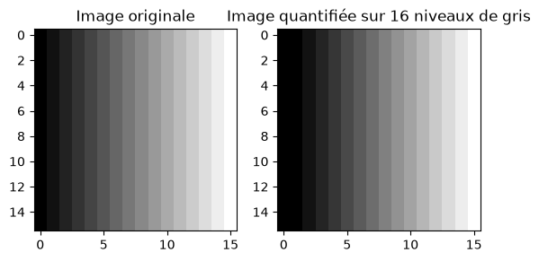

```python
import matplotlib as mp
from matplotlib import pyplot

print(tab)
long_tab = len(tab)
mon_image = []

# construction de l'image à partir de copies de la ligne tab
for i in range(long_tab):
    mon_image.append(tab.copy())
    # vérification des identifiants --> ils doivent être différents
    print('-----', id(mon_image[i]))


copie_mon_image = [ligne[:] for ligne in mon_image]  # pas mon_image.copy() car cela ne change pas les identifiants des lignes de l'image du coup on ne peut pas modifier l'image sans modifier l'originale
nb_niveau=int(input("Veuillez entrer le nombre de niveau de quantification de l'image pour le traitement :"))

for i in range(long_tab):
    for j in range(long_tab):
        for k in range(nb_niveau):
            if(copie_mon_image[i][j]<(k+1)*(256//nb_niveau)):
                copie_mon_image[i][j]=k
                break

print('liste de liste ', type(mon_image), '\n',type(mon_image[0]), '\n', mon_image)
print('liste de liste ', type(copie_mon_image), '\n',type(copie_mon_image[0]), '\n', copie_mon_image)

# visualisation de l'image en iveau de gris
mp.pyplot.subplot(1, 2, 1)
mp.pyplot.imshow(mon_image, cmap='gray')
mp.pyplot.title('Image originale')

mp.pyplot.subplot(1, 2, 2)
mp.pyplot.imshow(copie_mon_image, cmap='gray')
mp.pyplot.title('Image quantifiée sur '+str(nb_niveau)+' niveaux de gris')
```